# 1 Setup and reproducibility

# 16b Proximal Policy Optimization (PPO) on Env V2

```
[PPO-V2] steps=  4096 episodes= 128 last_ep_return=   0.00 loss=93292.680
[PPO-V2] steps=  8192 episodes= 256 last_ep_return=   0.00 loss=82705.750
[PPO-V2] steps= 12032 episodes= 376 last_ep_return=   0.00 loss=61792.539
[PPO-V2] steps= 16128 episodes= 504 last_ep_return=   0.00 loss=51584.223
[PPO-V2] steps= 20224 episodes= 632 last_ep_return=   0.00 loss=85934.500
[PPO-V2] steps= 24064 episodes= 752 last_ep_return=   0.00 loss=115288.562
[PPO-V2] steps= 28160 episodes= 880 last_ep_return=   0.00 loss=123045.992
[PPO-V2] steps= 32000 episodes=1000 last_ep_return=   0.00 loss=160485.172
[PPO-V2] steps= 36096 episodes=1128 last_ep_return=   0.00 loss=165910.547
[PPO-V2] steps= 40192 episodes=1256 last_ep_return=   0.00 loss=141218.359
[PPO-V2] steps= 44032 episodes=1376 last_ep_return=   0.00 loss=97765.602
[PPO-V2] steps= 48128 episodes=1504 last_ep_return=   0.00 loss=71147.461
[PPO-V2] steps= 52224 episodes=1632 last_ep_return=   0.00 loss=55269.398
[PPO-V2] steps= 56064 episodes=1752 last_ep_return=   0.00 loss=45558.699
[PPO-V2] steps= 60160 episodes=1880 last_ep_return=   0.00 loss=38868.406
[PPO-V2] steps= 64000 episodes=2000 last_ep_return=   0.00 loss=42883.812
[PPO-V2] steps= 68096 episodes=2128 last_ep_return=   0.00 loss=43726.648
[PPO-V2] steps= 72192 episodes=2256 last_ep_return=   0.00 loss=49500.785
[PPO-V2] steps= 76032 episodes=2376 last_ep_return=   0.00 loss=48949.883
[PPO-V2] steps= 80000 episodes=2500 last_ep_return=   0.00 loss=79316.977
Saved: report_artifacts/ppo_rewards_envv2_20251124_221118.png
                policy  mean_cost_v2  mean_cost_v2_ci_lo  mean_cost_v2_ci_hi  \
3                 ddqn  -1346.245361        -1401.005005        -1288.222046
2    bandit_ctx_linucb  -1346.245361        -1401.005005        -1288.222046
6          no_overbook  -1346.245361        -1401.005005        -1288.222046
4                  dqn  -1346.245361        -1401.005005        -1288.222046
7                  ppo  -1346.245361        -1401.005005        -1288.222046
8               random    -96.389069         -177.450027           -5.695798
5        mild_overbook    -33.649994         -118.113251           45.052849
0                  a2c     -5.478119          -96.615623           78.094322
1  aggressive_overbook     -5.478119          -96.615623           78.094322

       var5_v2     cvar5_v2     served  mean_revenue  mean_shortfall_penalty
3  -483.875000  -223.915375  52.980469   2649.023438              211.054688
2  -483.875000  -223.915375  52.980469   2649.023438              211.054688
6  -483.875000  -223.915375  52.980469   2649.023438              211.054688
4  -483.875000  -223.915375  52.980469   2649.023438              211.054688
7  -483.875000  -223.915375  52.980469   2649.023438              211.054688
8  1160.025024  1384.138550  59.875000   2993.750000               42.890625
5  1037.949951  1345.976685  59.925781   2996.289062               40.781250
0  1319.750000  1539.192261  60.011719   3000.585938               36.914062
1  1319.750000  1539.192261  60.011719   3000.585938               36.914062
Saved: report_artifacts/ecdf_envv2_ppo_20251124_221125.png
```

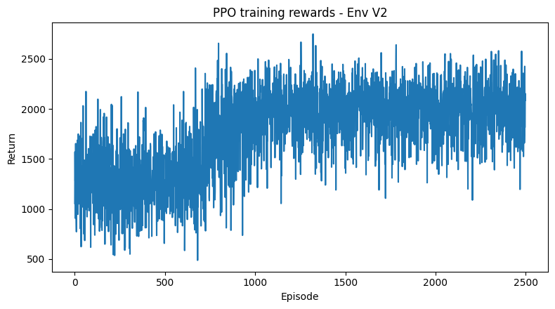

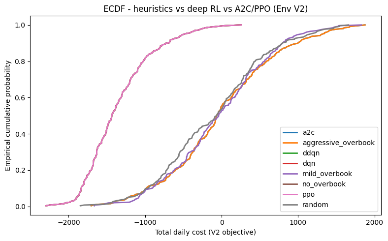

```python
def train_ppo_v2(env_cfg: ClinicConfig,
                 total_env_steps: int = 80_000,
                 rollout_len: int = 256,
                 gamma: float = 0.99,
                 lam: float = 0.95,
                 clip_ratio: float = 0.2,
                 train_epochs: int = 4,
                 target_kl: float = 0.01,
                 entropy_coef: float = 0.0,
                 value_coef: float = 0.5,
                 max_grad_norm: float = 0.5,
                 lr: float = 3e-4,
                 print_every: int = 4_000):
    """
    Train a PPO agent on ClinicEnvV2 using batch rollouts and a clipped
    surrogate objective.
    """
    env = ClinicEnvV2(env_cfg)
    obs_dim = env.observation_space.shape[0]
    n_actions = env.action_space.n

    ac = ActorCritic(obs_dim, n_actions).to(device)
    opt = optim.Adam(ac.parameters(), lr=lr)

    obs, _ = env.reset(seed=env_cfg.seed)
    steps = 0
    episode_return = 0.0
    ep_returns = []
    losses = []

    while steps < total_env_steps:
        obs_buf, act_buf = [], []
        logp_old_buf, val_buf = [], []
        rew_buf, done_buf = [], []

        # Collect one rollout
        for t in range(rollout_len):
            x = torch.tensor(obs, dtype=torch.float32, device=device).unsqueeze(0)
            logits, v = ac(x)
            dist = torch.distributions.Categorical(logits=logits)
            a = dist.sample()

            log_p = dist.log_prob(a).squeeze(0)
            obs_buf.append(obs.copy())
            act_buf.append(int(a.item()))
            logp_old_buf.append(log_p.detach())
            val_buf.append(v.squeeze(0).detach())

            obs2, r, term, trunc, _ = env.step(int(a.item()))
            done = float(term or trunc)

            rew_buf.append(float(r))
            done_buf.append(done)

            steps += 1
            episode_return += float(r)
            obs = obs2

            if term or trunc:
                ep_returns.append(episode_return)
                episode_return = 0.0
                obs, _ = env.reset()

            if steps >= total_env_steps:
                break

        # Advantage and return computation (GAE)
        with torch.no_grad():
            x_last = torch.tensor(obs, dtype=torch.float32, device=device).unsqueeze(0)
            _, v_last = ac(x_last)
            v_last = v_last.squeeze(0)

        rewards = torch.tensor(rew_buf, dtype=torch.float32, device=device)
        dones = torch.tensor(done_buf, dtype=torch.float32, device=device)
        values = torch.stack(val_buf).to(device)

        T = rewards.shape[0]
        advantages = torch.zeros(T, dtype=torch.float32, device=device)
        last_gae = 0.0
        for t in reversed(range(T)):
            next_nonterminal = 1.0 - (dones[t] if t < T - 1 else 0.0)
            next_value = v_last if t == T - 1 else values[t + 1]
            delta = rewards[t] + gamma * next_value * next_nonterminal - values[t]
            last_gae = delta + gamma * lam * next_nonterminal * last_gae
            advantages[t] = last_gae

        returns = advantages + values
        advantages = (advantages - advantages.mean()) / (advantages.std() + 1e-8)

        obs_tensor = torch.tensor(np.array(obs_buf),
                                  dtype=torch.float32,
                                  device=device)
        act_tensor = torch.tensor(act_buf, dtype=torch.int64, device=device)
        logp_old = torch.stack(logp_old_buf).to(device)

        # PPO updates on this rollout
        for epoch in range(train_epochs):
            logits, v_pred = ac(obs_tensor)
            dist = torch.distributions.Categorical(logits=logits)
            logp = dist.log_prob(act_tensor)
            entropy = dist.entropy().mean()

            ratio = torch.exp(logp - logp_old)
            surr1 = ratio * advantages
            surr2 = torch.clamp(ratio, 1.0 - clip_ratio,
                                1.0 + clip_ratio) * advantages
            policy_loss = -torch.min(surr1, surr2).mean()

            value_loss = (returns - v_pred).pow(2).mean()

            loss = policy_loss + value_coef * value_loss - entropy_coef * entropy

            opt.zero_grad()
            loss.backward()
            nn.utils.clip_grad_norm_(ac.parameters(), max_grad_norm)
            opt.step()

            with torch.no_grad():
                approx_kl = (logp_old - logp).mean().item()
            if approx_kl > 1.5 * target_kl:
                # Early stop this epoch if the update is too aggressive
                break

        losses.append(float(loss.item()))

        if steps % print_every < rollout_len:
            print(f"[PPO-V2] steps={steps:6d} "
                  f"episodes={len(ep_returns):4d} "
                  f"last_ep_return={episode_return:7.2f} "
                  f"loss={loss.item():.3f}")

    logs = {
        "rewards": np.array(ep_returns, dtype=np.float32),
        "losses": np.array(losses, dtype=np.float32),
    }
    return ac, logs


# Train PPO on Env V2

ac_ppo_v2, logs_ppo_v2 = train_ppo_v2(
    cfg,
    total_env_steps=80_000,
    rollout_len=256,
    gamma=0.99,
    lam=0.95,
    clip_ratio=0.2,
    train_epochs=4,
    target_kl=0.01,
    entropy_coef=0.0,
    value_coef=0.5,
    max_grad_norm=0.5,
    lr=3e-4,
    print_every=4_000,
)

plt.figure(figsize=(8, 4.5))
plt.plot(logs_ppo_v2["rewards"])
plt.xlabel("Episode")
plt.ylabel("Return")
plt.title("PPO training rewards - Env V2")
plt.tight_layout()
path_ppo_rewards_v2 = os.path.join(ART_DIR, f"ppo_rewards_envv2_{now_tag()}.png")
plt.savefig(path_ppo_rewards_v2, dpi=120)
print("Saved:", path_ppo_rewards_v2)


# Evaluate PPO alongside all other methods

df_ppo_v2 = evaluate_policy_v2_actor(ac_ppo_v2, cfg, episodes=256).assign(policy="ppo")

df_h_v2 = eval_policies_v2(cfg, POLICIES, episodes=256)
frames = [df_h_v2, df_ppo_v2]

for net, name in [
    (qnet_dqn_v2 if 'qnet_dqn_v2' in globals() else None, "dqn"),
    (qnet_ddqn_v2 if 'qnet_ddqn_v2' in globals() else None, "ddqn"),
]:
    if net is not None:
        frames.append(evaluate_greedy_v2(net, cfg, episodes=256).assign(policy=name))

if 'ac_a2c_v2' in globals():
    frames.append(df_a2c_v2)  # already has policy="a2c"

if 'df_lin' in globals():

    frames.append(df_lin)

df_all_ppo_v2 = pd.concat(frames, ignore_index=True)

summary_ppo_v2 = summarize_v2(df_all_ppo_v2, alpha=0.05)
print(summary_ppo_v2)

plt.figure(figsize=(8, 5))
for name, g in df_all_ppo_v2.groupby("policy"):
    if name not in [
        "no_overbook",
        "mild_overbook",
        "aggressive_overbook",
        "random",
        "dqn",
        "ddqn",
        "a2c",
        "ppo",
    ]:
        continue
    y, x = ecdf(g["cost_total_v2"].to_numpy())
    plt.plot(y, x, label=name, linewidth=2.0)

plt.xlabel("Total daily cost (V2 objective)")
plt.ylabel("Empirical cumulative probability")
plt.title("ECDF - heuristics vs deep RL vs A2C/PPO (Env V2)")
plt.legend()
plt.tight_layout()
path_ecdf_ppo_v2 = os.path.join(ART_DIR, f"ecdf_envv2_ppo_{now_tag()}.png")
plt.savefig(path_ecdf_ppo_v2, dpi=130)
print("Saved:", path_ecdf_ppo_v2)
```

# 17 Rainbow-style DQN on Env V2

Here the project incorporates several improvements from the Rainbow DQN family in a simplified way. A dueling network architecture is used to separate state-value and action-advantage streams, and a prioritized replay buffer is introduced so that transitions with larger TD errors are replayed more often. The target is still based on a Double DQN formulation, and standard techniques such as gradient clipping are applied. Rainbow is trained on Env V2 and evaluated against earlier methods, with a focus on whether these architectural and sampling enhancements lead to better mean and tail costs. The section positions Rainbow as a stronger value-based baseline before moving to distributional RL.

```
[Rainbow-V2] step=  4000 episodes= 125 last_return=1040.90
[Rainbow-V2] step=  8000 episodes= 250 last_return=1351.56
[Rainbow-V2] step= 12000 episodes= 375 last_return=1114.50
[Rainbow-V2] step= 16000 episodes= 500 last_return=1713.22
[Rainbow-V2] step= 20000 episodes= 625 last_return=2150.11
[Rainbow-V2] step= 24000 episodes= 750 last_return=1914.10
[Rainbow-V2] step= 28000 episodes= 875 last_return=1416.19
[Rainbow-V2] step= 32000 episodes=1000 last_return=1843.09
[Rainbow-V2] step= 36000 episodes=1125 last_return=1869.33
[Rainbow-V2] step= 40000 episodes=1250 last_return=1567.67
Saved: report_artifacts/rainbow_rewards_envv2_20251124_231525.png
                policy  mean_cost_v2  mean_cost_v2_ci_lo  mean_cost_v2_ci_hi  \
3                 ddqn  -1346.245361        -1401.005005        -1288.222046
2    bandit_ctx_linucb  -1346.245361        -1401.005005        -1288.222046
6          no_overbook  -1346.245361        -1401.005005        -1288.222046
4                  dqn  -1346.245361        -1401.005005        -1288.222046
7                  ppo  -1346.245361        -1401.005005        -1288.222046
8              rainbow  -1346.245361        -1401.005005        -1288.222046
9               random   -101.002731         -195.150650          -15.347328
5        mild_overbook    -33.649994         -118.113251           45.052849
1  aggressive_overbook     -5.478119          -96.615623           78.094322
0                  a2c     -5.478119          -96.615623           78.094322

       var5_v2     cvar5_v2     served  mean_revenue  mean_shortfall_penalty
3  -483.875000  -223.915375  52.980469   2649.023438              211.054688
2  -483.875000  -223.915375  52.980469   2649.023438              211.054688
6  -483.875000  -223.915375  52.980469   2649.023438              211.054688
4  -483.875000  -223.915375  52.980469   2649.023438              211.054688
7  -483.875000  -223.915375  52.980469   2649.023438              211.054688
8  -483.875000  -223.915375  52.980469   2649.023438              211.054688
9  1144.950073  1507.607666  59.847656   2992.382812               43.828125
5  1037.949951  1345.976685  59.925781   2996.289062               40.781250
1  1319.750000  1539.192261  60.011719   3000.585938               36.914062
0  1319.750000  1539.192261  60.011719   3000.585938               36.914062
Saved: report_artifacts/ecdf_envv2_rainbow_20251124_231533.png
```

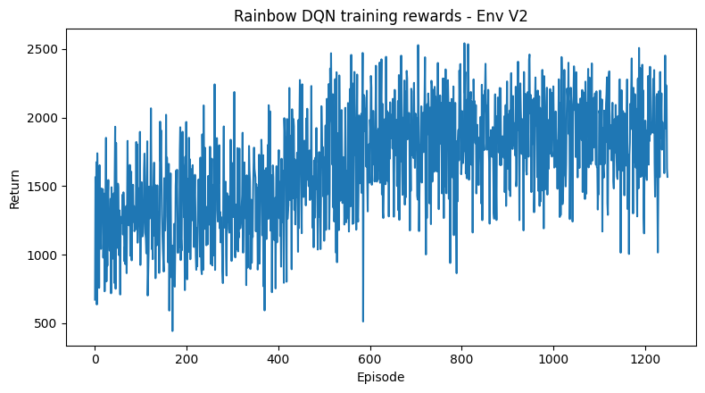

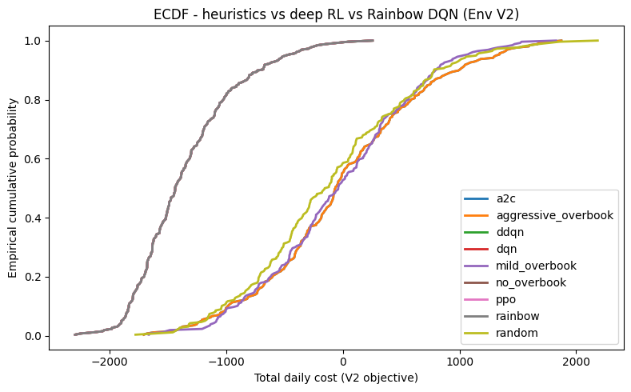

```python
# Dueling Q-network for Rainbow-style DQN

class DuelingQNet(nn.Module):
    def __init__(self, obs_dim: int, n_actions: int):
        super().__init__()
        self.shared = nn.Sequential(
            nn.Linear(obs_dim, 128), nn.ReLU(),
            nn.Linear(128, 128), nn.ReLU(),
        )
        self.value_head = nn.Linear(128, 1)
        self.adv_head = nn.Linear(128, n_actions)

    def forward(self, x: torch.Tensor):
        h = self.shared(x)
        v = self.value_head(h)              # [B, 1]
        a = self.adv_head(h)               # [B, A]
        # Q(s,a) = V(s) + (A(s,a) - mean_a A(s,a))
        a_mean = a.mean(dim=1, keepdim=True)
        q = v + (a - a_mean)
        return q


# Prioritized replay buffer (simple proportional PER)

class PrioritizedReplayBuffer:
    def __init__(self,
                 capacity: int = 50_000,
                 alpha: float = 0.6,
                 beta_start: float = 0.4,
                 beta_end: float = 1.0,
                 beta_steps: int = 40_000):
        self.capacity = capacity
        self.alpha = alpha
        self.beta_start = beta_start
        self.beta_end = beta_end
        self.beta_steps = max(1, beta_steps)

        self.states = np.zeros((capacity,), dtype=object)
        self.actions = np.zeros((capacity,), dtype=np.int64)
        self.rewards = np.zeros((capacity,), dtype=np.float32)
        self.next_states = np.zeros((capacity,), dtype=object)
        self.dones = np.zeros((capacity,), dtype=np.float32)
        self.prios = np.zeros((capacity,), dtype=np.float32)

        self.ptr = 0
        self.size = 0
        self.step = 0

    def push(self, s, a, r, s2, done):
        idx = self.ptr
        self.states[idx] = s
        self.actions[idx] = a
        self.rewards[idx] = r
        self.next_states[idx] = s2
        self.dones[idx] = done

        max_prio = self.prios.max() if self.size > 0 else 1.0
        self.prios[idx] = max_prio

        self.ptr = (self.ptr + 1) % self.capacity
        self.size = min(self.size + 1, self.capacity)

    def _beta(self):
        # Anneal beta linearly from beta_start to beta_end
        t = min(1.0, self.step / float(self.beta_steps))
        return self.beta_start + t * (self.beta_end - self.beta_start)

    def sample(self, batch_size: int):
        self.step += 1
        size = self.size
        prios = self.prios[:size].astype(np.float64)
        if prios.sum() == 0.0:
            prios[:] = 1.0
        probs = prios ** self.alpha
        probs /= probs.sum()

        idxs = np.random.choice(size, batch_size, p=probs)
        beta = self._beta()
        weights = (size * probs[idxs]) ** (-beta)
        weights /= weights.max()  # normalize to [0,1]
        weights = weights.astype(np.float32)

        s = np.stack(self.states[idxs]).astype(np.float32)
        s2 = np.stack(self.next_states[idxs]).astype(np.float32)
        a = self.actions[idxs]
        r = self.rewards[idxs]
        d = self.dones[idxs]

        # convert to tensors
        s_t = torch.tensor(s, dtype=torch.float32, device=device)
        s2_t = torch.tensor(s2, dtype=torch.float32, device=device)
        a_t = torch.tensor(a, dtype=torch.int64, device=device).unsqueeze(1)
        r_t = torch.tensor(r, dtype=torch.float32, device=device).unsqueeze(1)
        d_t = torch.tensor(d, dtype=torch.float32, device=device).unsqueeze(1)
        w_t = torch.tensor(weights, dtype=torch.float32, device=device).unsqueeze(1)

        return (s_t, a_t, r_t, s2_t, d_t, w_t, idxs)

    def update_priorities(self, idxs, td_errors, eps: float = 1e-6):
        td = np.abs(td_errors.detach().cpu().numpy()).flatten()
        for i, e in zip(idxs, td):
            self.prios[i] = e + eps


def train_step_rainbow(qnet: DuelingQNet,
                       tgt: DuelingQNet,
                       opt: torch.optim.Optimizer,
                       batch,
                       gamma: float = 0.99) -> float:
    """
    One Rainbow-style Double DQN update with prioritized replay.
    """
    s, a, r, s2, d, w, idxs = batch

    # Q(s,a) from online dueling network
    q_sa = qnet(s).gather(1, a)

    with torch.no_grad():
        # Double DQN target:
        # a* = argmax_a Q_online(s', a)
        q_next_online = qnet(s2)
        a_star = q_next_online.argmax(dim=1, keepdim=True)

        # evaluate with target network
        q_next_target = tgt(s2).gather(1, a_star)
        y = r + (1.0 - d) * gamma * q_next_target

    td_error = y - q_sa
    # Huber loss with importance-sampling weights
    loss_per_sample = nn.functional.smooth_l1_loss(
        q_sa, y, reduction="none"
    )
    loss = (w * loss_per_sample).mean()

    opt.zero_grad()
    loss.backward()
    nn.utils.clip_grad_norm_(qnet.parameters(), 1.0)
    opt.step()

    return float(loss.item()), td_error


def run_rainbow_v2(env_cfg: ClinicConfig,
                   steps_total: int = 40_000,
                   batch_size: int = 64,
                   start_learning: int = 1_000,
                   target_sync: int = 2_000,
                   gamma: float = 0.99,
                   lr: float = 1e-3,
                   print_every: int = 2_000):
    """
    Train a Rainbow-style DQN agent (dueling + Double DQN + PER)
    directly on ClinicEnvV2.
    """
    env = ClinicEnvV2(env_cfg)
    obs_dim = env.observation_space.shape[0]
    n_actions = env.action_space.n

    qnet = DuelingQNet(obs_dim, n_actions).to(device)
    tgt = DuelingQNet(obs_dim, n_actions).to(device)
    tgt.load_state_dict(qnet.state_dict())

    opt = optim.Adam(qnet.parameters(), lr=lr)
    buf = PrioritizedReplayBuffer(
        capacity=50_000,
        alpha=0.6,
        beta_start=0.4,
        beta_end=1.0,
        beta_steps=steps_total,
    )

    obs, _ = env.reset(seed=env_cfg.seed)
    ep_return = 0.0
    rewards = []
    losses = []
    episodes = 0

    for step in range(1, steps_total + 1):
        eps = dqn_epsilon(
            step,
            eps_start=1.0,
            eps_end=0.05,
            eps_decay_steps=20_000,
        )
        a = select_action(qnet, obs, env, eps)
        obs2, r, term, trunc, _ = env.step(a)
        done_flag = float(term or trunc)

        buf.push(obs.astype(np.float32), a, r, obs2.astype(np.float32), done_flag)
        obs = obs2
        ep_return += r

        if term or trunc:
            rewards.append(ep_return)
            episodes += 1
            if step % print_every == 0:
                print(f"[Rainbow-V2] step={step:6d} "
                      f"episodes={episodes:4d} "
                      f"last_return={ep_return:7.2f}")
            ep_return = 0.0
            obs, _ = env.reset()

        if buf.size >= start_learning:
            batch = buf.sample(batch_size)
            loss, td_error = train_step_rainbow(qnet, tgt, opt, batch, gamma=gamma)
            losses.append(loss)
            # update priorities
            _, _, _, _, _, _, idxs = batch
            buf.update_priorities(idxs, td_error)

        if step % target_sync == 0:
            tgt.load_state_dict(qnet.state_dict())

    logs = {
        "rewards": np.array(rewards, dtype=np.float32),
        "losses": np.array(losses, dtype=np.float32),
    }
    return qnet, logs


# Train Rainbow-style DQN on Env V2

qnet_rainbow_v2, logs_rainbow_v2 = run_rainbow_v2(
    cfg,
    steps_total=40_000,
    batch_size=64,
    start_learning=1_000,
    target_sync=2_000,
    gamma=0.99,
    lr=1e-3,
    print_every=2_000,
)

plt.figure(figsize=(8, 4.5))
plt.plot(logs_rainbow_v2["rewards"])
plt.xlabel("Episode")
plt.ylabel("Return")
plt.title("Rainbow DQN training rewards - Env V2")
plt.tight_layout()
path_rainbow_rewards_v2 = os.path.join(
    ART_DIR, f"rainbow_rewards_envv2_{now_tag()}.png"
)
plt.savefig(path_rainbow_rewards_v2, dpi=120)
print("Saved:", path_rainbow_rewards_v2)


# Evaluate Rainbow DQN alongside other methods on V2 objective

df_rainbow_v2 = evaluate_greedy_v2(
    qnet_rainbow_v2, cfg, episodes=256
).assign(policy="rainbow")

df_h_v2 = eval_policies_v2(cfg, POLICIES, episodes=256)
frames = [df_h_v2, df_rainbow_v2]

# add value-based and actor-critic methods
for name, net in [
    ("dqn",      globals().get("qnet_dqn_v2", None)),
    ("ddqn",     globals().get("qnet_ddqn_v2", None)),
    ("a2c",      None),  # handled via df_a2c_v2
    ("ppo",      None),  # handled via df_ppo_v2
]:
    if net is not None:
        frames.append(
            evaluate_greedy_v2(net, cfg, episodes=256).assign(policy=name)
        )

if "df_a2c_v2" in globals():
    frames.append(df_a2c_v2)
if "df_all_ppo_v2" in globals():
    # df_all_ppo_v2 already includes multiple policies
    # but df_ppo_v2 is the PPO-only frame we created earlier
    try:
        frames.append(df_ppo_v2)
    except NameError:
        pass
if "df_lin" in globals():
    frames.append(df_lin)  # LinUCB contextual bandit

df_all_rainbow_v2 = pd.concat(frames, ignore_index=True)

summary_rainbow_v2 = summarize_v2(df_all_rainbow_v2, alpha=0.05)
print(summary_rainbow_v2)

plt.figure(figsize=(8, 5))
for name, g in df_all_rainbow_v2.groupby("policy"):
    if name not in [
        "no_overbook",
        "mild_overbook",
        "aggressive_overbook",
        "random",
        "dqn",
        "ddqn",
        "a2c",
        "ppo",
        "rainbow",
    ]:
        continue
    y, x = ecdf(g["cost_total_v2"].to_numpy())
    plt.plot(y, x, label=name, linewidth=2.0)

plt.xlabel("Total daily cost (V2 objective)")
plt.ylabel("Empirical cumulative probability")
plt.title("ECDF - heuristics vs deep RL vs Rainbow DQN (Env V2)")
plt.legend()
plt.tight_layout()
path_ecdf_rainbow_v2 = os.path.join(
    ART_DIR, f"ecdf_envv2_rainbow_{now_tag()}.png"
)
plt.savefig(path_ecdf_rainbow_v2, dpi=130)
print("Saved:", path_ecdf_rainbow_v2)
```